# R Notebook

## B2

1. Open and explore the NHANES dataset in R through the following steps: • Install the NHANES R package: install.packages(“NHANES”) • Load the R package: library(NHANES) • Load the NHANES dataset into your workspace: data(NHANES)

```r
#install.packages("NHANES")
library(NHANES)
data(NHANES)
head(NHANES)
```

– Use the command ? to access the help page for the dataset: ?NHANES Review the dataset documentation, particularly looking (i) What was the purpose for collecting the data?

```r
# Oversampled certain subpopulations like racial minorities so that weighting is adjusted.

## Prof's Logic: The data were collected to monitor the health and nutrition of children and adults in the United States.
```

2. When and how were the data in the dataset collected?

```r
# Sample years from 2009-2010 and 2011-2012.
# Dataset is collected through individuals being interviewed in their homes every year and complete the health examination component of the survey. The health examination is conducted in a mobile examination centre (MEC).
```

3. What is the target population of the sample?

```r
# The NHANES target population is "the non-institutionalized civilian resident population of the United States".
```

4. What is the sample size? Who was eligible to be included in the dataset? Are there different eligibility or inclusion criteria for certain variables?

```r
# raw sample size is 20,293 but adjusted is 10,000
# Those who have homes and that complete the health examiniation and interview
```

22. What are the areas of information available in the dataset?

```r
# Study variables
# Demographic variables
# Physical measurements
# Health variables
# Lifestyle variabes
```

In the documentation, note that several of the variables are only collected for respondents of a certain age range or in one of the survey rounds but not the other. This is important to take note because it may affect what questions can be addressed by the data, or result in errant conclusions and incorrect interpretation if eligibility and inclusion criteria are not appropriately considered during analysis.

For the remainder of the tutorial, we will only consider the subset of the sample who are adults aged 20 years and older. Construct this dataset with the R command: nhanes20pl <- NHANES[NHANES$Age >= 20, ]

```r
nhanes20pl <- NHANES[NHANES$Age >= 20, ]
```

6. Confirm that your new dataset has 7235 respondents remaining. Use at least one different R command to achieve construction of the same subsetted dataset. Confirm that your alternate command has the same number of rows and columns.

```r
nrow(nhanes20pl)
ncol(nhanes20pl)

nhanes20pl_subset <- subset(NHANES,
                            Age >= 20)
# alternatives:
  # NHANES[which(NHANES$Age >= 20), ]
  # filter(NHANAES, Age >= 20)
nrow(nhanes20pl_subset)
ncol(nhanes20pl_subset)
```

2. Types of variables. Using the subsetted nhanes20pl dataset, identify at least one variable of each of the types of variables: continuous, discrete numeric, binary, categorical, and ordered categorical. For an identified variable of each type, create an appropriate summary of the frequency distribution and calculate an appropriate measure of central tendency and variation.

```r
#str(nhanes20pl)

# continuous: Poverty
# discrete numeric: HomeRooms
# binary:SleepTrouble
# categorical: Race1
# ordered categorical: AgeDecade

#  appropriate summary of the frequency distribution and calculate an appropriate measure of central tendency and variation.
hist(nhanes20pl$Poverty)
mean(na.omit(nhanes20pl$Poverty)) # 2.944494
sd(na.omit(nhanes20pl$Poverty)) # 1.665132

hist(nhanes20pl$HomeRooms)
mean(na.omit(nhanes20pl$HomeRooms)) # 6.142201
sd(na.omit(nhanes20pl$HomeRooms)) # 2.260319

hist(as.numeric(nhanes20pl$SleepTrouble))
mean(na.omit(as.numeric(nhanes20pl$SleepTrouble))) # 1.263994
sd(na.omit(as.numeric(nhanes20pl$SleepTrouble))) # 0.4408268

hist(as.numeric(nhanes20pl$Race1))
mean(na.omit(as.numeric(nhanes20pl$Race1))) # 3.537249
sd(na.omit(as.numeric(nhanes20pl$Race1))) # 1.093671

hist(as.numeric(nhanes20pl$AgeDecade))
mean(na.omit(as.numeric(nhanes20pl$AgeDecade))) # 5.123587
sd(na.omit(as.numeric(nhanes20pl$AgeDecade))) # 1.565809
```

3. Frequency distributions. Identify at least one variable in the dataset that has a frequency distribution matching each of the shapes described in Kirkman and Sterne Figures 3.5 and 3.6 (pages 20-21). For each of the identified variables, calculated the mean, median, mode, variance, standard devation, range, and interquartile range.

```r
getmode <- function(v) {
   uniqv <- unique(v)
   uniqv[which.max(tabulate(match(v, uniqv)))]
}
```

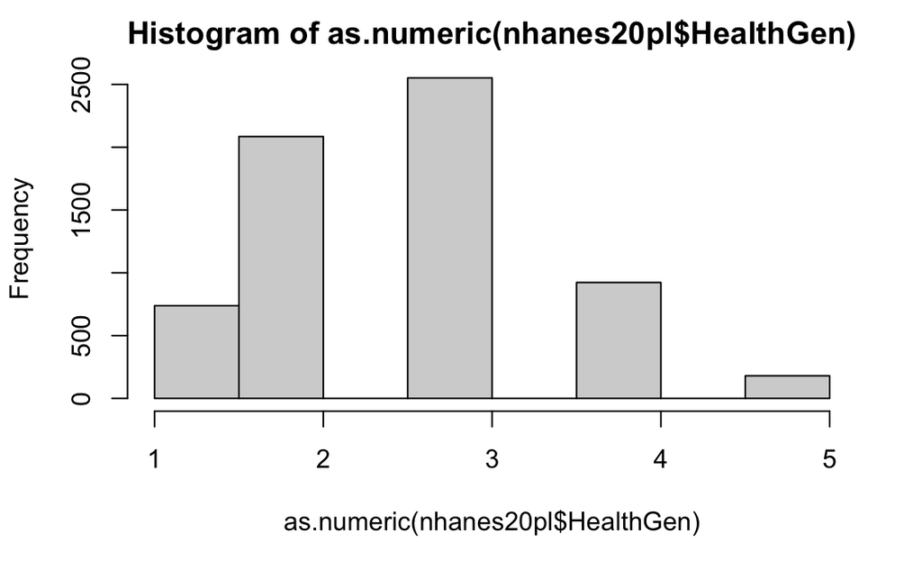

```r
# symmetrical and bell shaped: HealthGen
hist(as.numeric(nhanes20pl$HealthGen))
```

```r
mean(na.omit(as.numeric(nhanes20pl$HealthGen))) # 2.648348
```

```
[1] 2.648348
```

```r
median(na.omit(as.numeric(nhanes20pl$HealthGen))) # 3
```

```
[1] 3
```

```r
getmode(na.omit(as.numeric(nhanes20pl$HealthGen))) # 3
```

```
[1] 3
```

```r
var(na.omit(as.numeric(nhanes20pl$HealthGen))) # 0.9076636
```

```
[1] 0.9076636
```

```r
sd(na.omit(as.numeric(nhanes20pl$HealthGen))) # 0.9527138
```

```
[1] 0.9527138
```

```r
range(na.omit(as.numeric(nhanes20pl$HealthGen))) # 1 5
```

```
[1] 1 5
```

```r
IQR(na.omit(as.numeric(nhanes20pl$HealthGen))) # 1
```

```
[1] 1
```

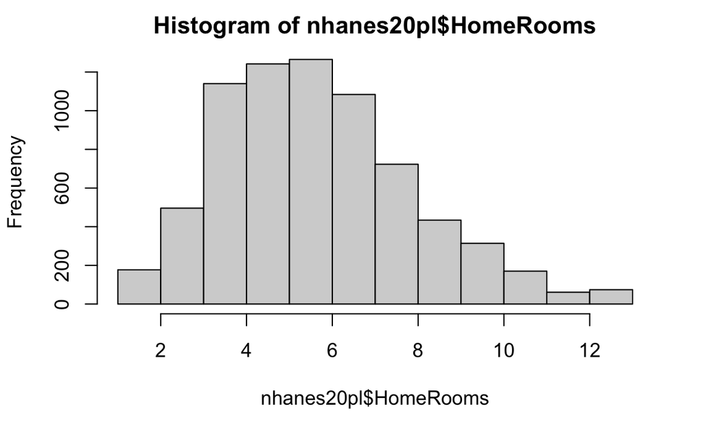

```r
# positively skewed to right: HomeRooms
hist(nhanes20pl$HomeRooms)
```

```r
mean(na.omit(nhanes20pl$HomeRooms)) # 6.142201
```

```
[1] 6.142201
```

```r
median(na.omit(nhanes20pl$HomeRooms)) # 6
```

```
[1] 6
```

```r
getmode(na.omit(nhanes20pl$HomeRooms)) # 6
```

```
[1] 6
```

```r
var(na.omit(nhanes20pl$HomeRooms)) # 5.109042
```

```
[1] 5.109042
```

```r
sd(na.omit(nhanes20pl$HomeRooms)) # 2.260319
```

```
[1] 2.260319
```

```r
range(na.omit(nhanes20pl$HomeRooms)) # 1 13
```

```
[1]  1 13
```

```r
IQR(na.omit(nhanes20pl$HomeRooms)) # 3
```

```
[1] 3
```

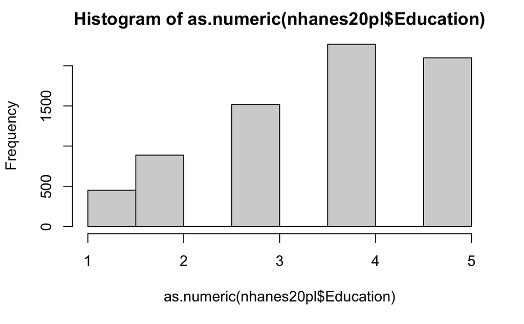

```r
# negatively skewed to left:Education
hist(as.numeric(nhanes20pl$Education))
```

```r
mean(na.omit(as.numeric(nhanes20pl$Education))) # 3.64714
```

```
[1] 3.64714
```

```r
median(na.omit(as.numeric(nhanes20pl$Education))) # 4
```

```
[1] 4
```

```r
getmode(na.omit(as.numeric(nhanes20pl$Education))) # 4
```

```
[1] 4
```

```r
var(na.omit(as.numeric(nhanes20pl$Education))) # 1.43032
```

```
[1] 1.43032
```

```r
sd(na.omit(as.numeric(nhanes20pl$Education))) # 1.19596
```

```
[1] 1.19596
```

```r
range(na.omit(as.numeric(nhanes20pl$Education))) # 1 5
```

```
[1] 1 5
```

```r
IQR(na.omit(as.numeric(nhanes20pl$Education))) # 2
```

```
[1] 2
```